# Spilhaus, as it flows downstream from PROJ: the R view

The companion to the Python notebook. Same sources, same sections, same landmarks, different runtime. The point is the same too: `+proj=spilhaus` arrived in **PROJ 9.6.0** (March 2025), and whether *this* R session can use it depends on which PROJ each package was linked against.

The stack here is deliberately low-level: **gdalraster** for I/O and the warp, **wk** for vertex-level geometry, **ximage** to draw a matrix. sf and terra appear only in the provenance table and in an appendix, as the same operation in one line, so you can see which PROJ each one silently used.

```r
SPILHAUS <- "+proj=spilhaus"
SPILHAUS_EXPLICIT <- paste(
  "+proj=spilhaus +lon_0=66.94970198 +lat_0=-49.56371678",
  "+azi=40.17823482 +rot=45 +k_0=1 +x_0=0 +y_0=0 +R=6378137"
)
SPILHAUS_ALT <- "+proj=spilhaus +lon_0=-30 +lat_0=-20 +azi=20 +rot=45"

GEBCO_URL <- "/vsicurl/https://data.source.coop/alexgleith/gebco-2024/GEBCO_2024.tif"
RASTER_URL <- Sys.getenv("SPILHAUS_RASTER", GEBCO_URL)

NE_OCEAN_URL <- paste0(
  "/vsicurl/https://raw.githubusercontent.com/nvkelso/natural-earth-vector/",
  "master/110m_physical/ne_110m_ocean.shp"
)
OCEAN_URL <- Sys.getenv("SPILHAUS_OCEAN", NE_OCEAN_URL)

NPIX <- as.integer(Sys.getenv("SPILHAUS_NPIX", "1600"))

Sys.setenv(GDAL_DISABLE_READDIR_ON_OPEN = "EMPTY_DIR",
           GDAL_HTTP_MULTIRANGE = "YES",
           GDAL_HTTP_MERGE_CONSECUTIVE_RANGES = "YES")
```

## 1. Who has which PROJ?

One row per package. `spilhaus` is the result of asking that package to make a CRS from `+proj=spilhaus`.

```r
probe <- function(expr) {
  out <- tryCatch({ force(expr); "ok" }, error = function(e) paste("FAIL:", conditionMessage(e)))
  substr(out, 1, 80)
}
has <- function(pkg) requireNamespace(pkg, quietly = TRUE)

rows <- list()

if (has("gdalraster")) {
  pv <- gdalraster::proj_version()
  rows$gdalraster <- data.frame(
    package = "gdalraster", version = as.character(packageVersion("gdalraster")),
    gdal = gdalraster::gdal_version()[4], proj = pv$name,
    spilhaus = probe(gdalraster::srs_to_wkt(SPILHAUS)))
} else rows$gdalraster <- data.frame(package = "gdalraster", version = NA, gdal = NA, proj = NA, spilhaus = "not installed")

if (has("PROJ")) {
  rows$PROJ <- data.frame(
    package = "PROJ", version = as.character(packageVersion("PROJ")),
    gdal = "-", proj = PROJ::proj_version(),
    spilhaus = probe(PROJ::proj_trans(cbind(147.33, -42.88), SPILHAUS, source = "OGC:CRS84")))
} else rows$PROJ <- data.frame(package = "PROJ", version = NA, gdal = "-", proj = NA, spilhaus = "not installed")

if (has("sf")) {
  v <- sf::sf_extSoftVersion()
  rows$sf <- data.frame(
    package = "sf", version = as.character(packageVersion("sf")),
    gdal = unname(v["GDAL"]), proj = unname(v["PROJ"]),
    spilhaus = probe({ x <- sf::st_crs(SPILHAUS); if (is.na(x)) stop("st_crs returned NA") }))
} else rows$sf <- data.frame(package = "sf", version = NA, gdal = NA, proj = NA, spilhaus = "not installed")

if (has("terra")) {
  rows$terra <- data.frame(
    package = "terra", version = as.character(packageVersion("terra")),
    gdal = terra::gdal(lib = "gdal"), proj = terra::gdal(lib = "proj"),
    spilhaus = probe({ x <- terra::crs(SPILHAUS); if (!nzchar(x)) stop("empty crs") }))
} else rows$terra <- data.frame(package = "terra", version = NA, gdal = NA, proj = NA, spilhaus = "not installed")

if (has("vapour")) {
  rows$vapour <- data.frame(
    package = "vapour", version = as.character(packageVersion("vapour")),
    gdal = vapour::vapour_gdal_version(), proj = vapour::vapour_proj_version(),
    spilhaus = probe(vapour::vapour_srs_wkt(SPILHAUS)))
}

if (has("wk")) rows$wk <- data.frame(package = "wk", version = as.character(packageVersion("wk")),
                                     gdal = "-", proj = "- (no PROJ dependency)", spilhaus = "n/a")
if (has("ximage")) rows$ximage <- data.frame(package = "ximage", version = as.character(packageVersion("ximage")),
                                             gdal = "-", proj = "-", spilhaus = "n/a")

provenance <- do.call(rbind, rows); rownames(provenance) <- NULL
knitr::kable(provenance, caption = sprintf("R %s on %s", getRversion(), R.version$platform))
```

R 4.6.1 on x86_64-pc-linux-gnu

| package | version | gdal | proj | spilhaus |
| --- | --- | --- | --- | --- |
| gdalraster | 2.6.1.9001 | 3.14.0dev-a9f9f9ed54 | 9.8.1 | ok |
| PROJ | 0.7.0 | - | 9.9.0 | ok |
| sf | 1.1.2 | 3.14.0dev-a9f9f9ed54 | 9.9.0 | ok |
| terra | 1.9.51 | 3.14.0dev-a9f9f9ed54 | 9.9.0 | ok |
| vapour | 0.16.0 | GDAL 3.14.0dev-a9f9f9ed54, released 2026/09/16 | 9.8.1 | ok |
| wk | 0.9.5 | - | - (no PROJ dependency) | n/a |
| ximage | 0.1.0 | - | - | n/a |

```r
cli_version <- function(cmd, args = "--version") {
  exe <- Sys.which(cmd)
  if (!nzchar(exe)) return("not found")
  out <- tryCatch(system2(exe, args, stdout = TRUE, stderr = TRUE), error = function(e) conditionMessage(e))
  out[1]
}
cli <- c(gdalinfo = cli_version("gdalinfo"),
         gdal = cli_version("gdal"),
         projinfo = cli_version("projinfo"))
knitr::kable(data.frame(tool = names(cli), version = unname(cli)), caption = "Command-line tools on PATH")
```

Command-line tools on PATH

| tool | version |
| --- | --- |
| gdalinfo | GDAL 3.14.0dev-a9f9f9ed54, released 2026/09/16 |
| gdal | GDAL 3.14.0dev-a9f9f9ed54, released 2026/09/16 |
| projinfo | Unrecognized option: –version |

```r
capable <- provenance$package[provenance$spilhaus == "ok" & provenance$package %in% c("gdalraster", "PROJ", "sf", "terra", "vapour")]
if (length(capable) == 0) stop("No installed package can create +proj=spilhaus on this machine; nothing below can run.")
ENGINE <- capable[1]
cat("Coordinate transforms below use:", ENGINE, "\n")
```

```
Coordinate transforms below use: gdalraster
```

```r
## forward/inverse constructors for any proj string, from the first capable package
make_forward <- function(proj_string) {
  switch(ENGINE,
    gdalraster = function(lonlat) gdalraster::transform_xy(lonlat, "OGC:CRS84", proj_string),
    PROJ       = function(lonlat) PROJ::proj_trans(lonlat, proj_string, source = "OGC:CRS84"),
    sf         = function(lonlat) sf::sf_project("OGC:CRS84", proj_string, lonlat, keep = TRUE),
    terra      = function(lonlat) terra::crds(terra::project(terra::vect(lonlat, crs = "OGC:CRS84"), proj_string)),
    vapour     = function(lonlat) vapour::vapour_project(lonlat, proj_string, "OGC:CRS84"))
}
make_inverse <- function(proj_string) {
  switch(ENGINE,
    gdalraster = function(xy) gdalraster::transform_xy(xy, proj_string, "OGC:CRS84"),
    PROJ       = function(xy) PROJ::proj_trans(xy, "OGC:CRS84", source = proj_string),
    sf         = function(xy) sf::sf_project(proj_string, "OGC:CRS84", xy, keep = TRUE),
    terra      = function(xy) terra::crds(terra::project(terra::vect(xy, crs = proj_string), "OGC:CRS84")),
    vapour     = function(xy) vapour::vapour_project(xy, "OGC:CRS84", proj_string))
}

## wrap: NaN where undefined, never error
safe <- function(f) function(m) {
  m <- matrix(as.numeric(m), ncol = 2)
  out <- tryCatch(f(m), error = function(e) matrix(NA_real_, nrow(m), 2))
  out <- matrix(as.numeric(out), ncol = 2)
  bad <- !is.finite(out[, 1]) | !is.finite(out[, 2]) | abs(out[, 1]) > 1e15 | abs(out[, 2]) > 1e15
  out[bad, ] <- NA_real_
  out
}
## inverse one point at a time so singular corners fail individually
pointwise <- function(f) function(m) {
  m <- matrix(as.numeric(m), ncol = 2)
  t(apply(m, 1, function(p) f(matrix(p, ncol = 2))))
}
forward <- safe(make_forward(SPILHAUS))
inverse <- pointwise(safe(make_inverse(SPILHAUS)))
```

## 2. The projection’s domain

PROJ does not publish the square’s half-width, so forward-project a dense lon/lat grid and take the extent; then inverse-project the square’s boundary to trace the cut on the globe.

```r
square_half <- function(fwd, n = 721) {
  g <- as.matrix(expand.grid(lon = seq(-180, 180, length.out = n), lat = seq(-90, 90, length.out = (n + 1) %/% 2)))
  xy <- fwd(g)
  ceiling(max(abs(xy), na.rm = TRUE) / 1000) * 1000
}
HALF <- square_half(forward)

n <- 300; t <- seq(-1, 1, length.out = n); edge <- 0.996 * HALF
boundary <- rbind(cbind(t * edge, -edge), cbind(edge, t * edge), cbind(rev(t) * edge, edge), cbind(-edge, rev(t) * edge))
cut <- inverse(boundary)
corners <- rbind(`corner A (Asia)` = c(115, 30), `corner B (South America)` = c(-65, -30))

cat(sprintf("Half-width %s m; %d of %d boundary samples inverted (misses cluster at the singular corners)\n",
            format(HALF, big.mark = ","), sum(complete.cases(cut)), nrow(cut)))
```

```
Half-width 11,803,000 m; 1172 of 1200 boundary samples inverted (misses cluster at the singular corners)
```

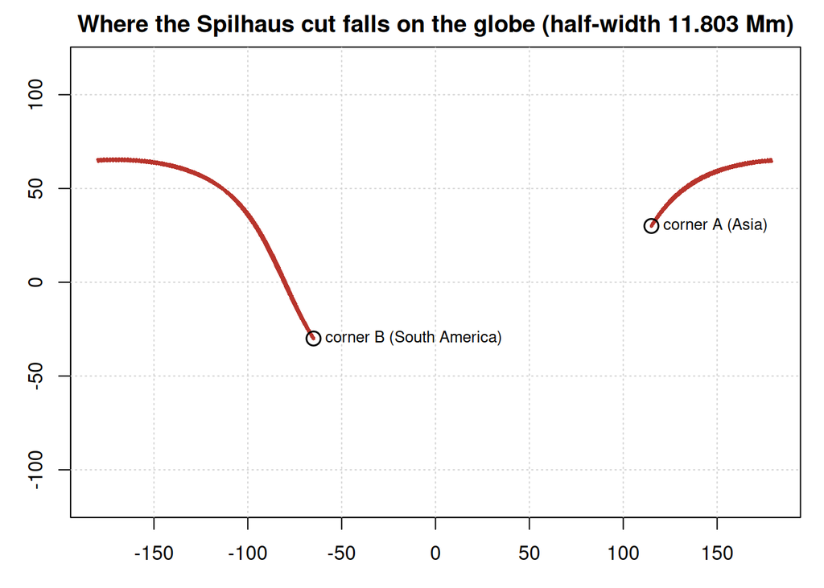

```r
op <- par(mar = c(3, 3, 2, 1))
plot(NA, xlim = c(-180, 180), ylim = c(-90, 90), asp = 1, xlab = "", ylab = "",
     main = sprintf("Where the Spilhaus cut falls on the globe (half-width %.3f Mm)", HALF / 1e6))
grid(); points(cut, pch = 16, cex = 0.4, col = "#b8342c")
points(corners, cex = 1.6, lwd = 1.5); text(corners, rownames(corners), pos = 4, cex = 0.8)
```

```r
par(op)
```

## 3. Raster: bathymetry over `/vsicurl`

`gdalraster::warp()` is GDAL’s warper with the same option vocabulary as `gdalwarp`, so the target extent and size are stated explicitly rather than estimated. The result is written to `/vsimem/` and read back as a matrix for **ximage**; nothing touches disk and only the tiles GDAL needs come over the wire.

```r
warp_square <- function(proj_string, half, npix, url = RASTER_URL, out = "/vsimem/spilhaus.tif") {
  t0 <- Sys.time()
  gdalraster::warp(url, out, t_srs = proj_string,
                   cl_arg = c("-te", -half, -half, half, half, "-ts", npix, npix,
                              "-r", "average", "-dstalpha", "-overwrite", "-q"))
  ds <- new(gdalraster::GDALRaster, out)
  on.exit(ds$close())
  v <- ds$read(band = 1, xoff = 0, yoff = 0, xsize = npix, ysize = npix, out_xsize = npix, out_ysize = npix)
  a <- ds$read(band = ds$getRasterCount(), xoff = 0, yoff = 0, xsize = npix, ysize = npix, out_xsize = npix, out_ysize = npix)
  m <- matrix(v, nrow = npix, ncol = npix, byrow = TRUE)   # row 1 = top of the image
  m[matrix(a, npix, npix, byrow = TRUE) == 0] <- NA
  list(z = m, res_m = 2 * half / npix, seconds = round(as.numeric(difftime(Sys.time(), t0, units = "secs")), 1),
       bands = ds$getRasterCount())
}
w <- warp_square(SPILHAUS, HALF, NPIX)
cat(sprintf("Warped %s to a %d x %d Spilhaus grid (%.1f km/px) in %s s\n",
            basename(RASTER_URL), NPIX, NPIX, w$res_m / 1000, w$seconds))
```

```
Warped GEBCO_2024.tif to a 1600 x 1600 Spilhaus grid (14.8 km/px) in 27 s
```

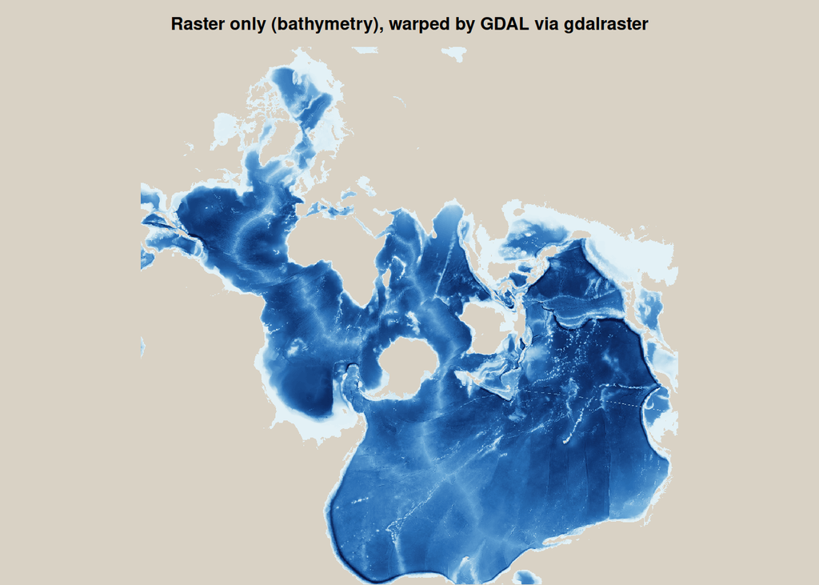

```r
bathy_cols <- grDevices::colorRampPalette(c("#08143f", "#123c7a", "#2a6fb5", "#6aa9d8", "#b9d9ea", "#e3f1f6"))(64)
render_raster <- function(z, half, add = FALSE) {
  ocean <- z; ocean[!is.na(z) & z >= 0] <- NA
  land  <- z; land[is.na(z) | z < 0] <- NA
  ximage::ximage(pmax(ocean, -7000), extent = c(-half, half, -half, half), asp = 1, col = bathy_cols,
                 zlim = c(-7000, 0), axes = FALSE, xlab = "", ylab = "", add = add)
  ximage::ximage(matrix(as.numeric(!is.na(land)), nrow(land)), extent = c(-half, half, -half, half),
                 zlim = c(0, 1), col = c(NA, "#d9d2c5"), add = TRUE)
}
op <- par(mar = c(0, 0, 2, 0), bg = "#d9d2c5")
render_raster(w$z, HALF)
title("Raster only (bathymetry), warped by GDAL via gdalraster", cex.main = 0.9)
```

```r
par(op)
```

## 4. Vector: Natural Earth ocean polygons, as vertices

Read remotely with gdalraster’s `GDALVector`, geometry returned as WKB, and handed to **wk**. From there the polygons are just a coordinate table with ring ids: transform the vertices, form segments between consecutive vertices of the same ring, and drop the segments that are absurdly long in projected space (those straddle the cut) or that are artefacts of the lon/lat representation (both ends on the antimeridian or at a pole). Coastlines are drawn as segments, not filled polygons.

```r
lyr <- new(gdalraster::GDALVector, OCEAN_URL)
lyr$returnGeomAs <- "WKB"
feat <- lyr$fetch(-1)
lyr$close()
geom_col <- which(vapply(feat, is.list, logical(1)))[1]  # the WKB column, whatever it is called
geom <- wk::wkb(feat[[geom_col]])
cat(sprintf("Ocean layer: %d feature(s), %s\n", length(geom), wk::wk_crs(geom)))

coast_segments <- function(geom, fwd, half, densify_deg = 0.5) {
  ## densify in lon/lat so the projected curves are smooth near the corners
  ## (wk has no densify; do it on the coordinate table)
  co <- wk::wk_coords(geom)
  key <- paste(co$feature_id, co$part_id, co$ring_id)
  dens <- do.call(rbind, lapply(split(co, key), function(r) {
    if (nrow(r) < 2) return(NULL)
    steps <- pmax(1L, ceiling(sqrt(diff(r$x)^2 + diff(r$y)^2) / densify_deg))
    x <- unlist(mapply(function(a, b, k) seq(a, b, length.out = k + 1)[-(k + 1)], r$x[-nrow(r)], r$x[-1], steps))
    y <- unlist(mapply(function(a, b, k) seq(a, b, length.out = k + 1)[-(k + 1)], r$y[-nrow(r)], r$y[-1], steps))
    data.frame(ring = r$ring_id[1] + 1e6 * r$feature_id[1], x = c(x, r$x[nrow(r)]), y = c(y, r$y[nrow(r)]))
  }))
  xy <- fwd(cbind(dens$x, dens$y))
  same_ring <- dens$ring[-1] == dens$ring[-nrow(dens)]
  step <- sqrt(diff(xy[, 1])^2 + diff(xy[, 2])^2)
  synthetic <- (abs(dens$x[-1]) > 179.99 & abs(dens$x[-nrow(dens)]) > 179.99) |
               (abs(dens$y[-1]) > 89.99 & abs(dens$y[-nrow(dens)]) > 89.99)
  ok <- same_ring & is.finite(step) & step < half / 8 & !synthetic
  i <- which(ok)
  cbind(x0 = xy[i, 1], y0 = xy[i, 2], x1 = xy[i + 1, 1], y1 = xy[i + 1, 2])
}
segs <- coast_segments(geom, forward, HALF)
cat(sprintf("%d coastline segments after projecting with %s and dropping cut-crossing segments\n", nrow(segs), ENGINE))
```

[output not shown]

```
11992 coastline segments after projecting with gdalraster and dropping cut-crossing segments
```

## 5. Points: landmarks, transformed directly

```r
landmarks <- rbind(
  Hobart = c(147.33, -42.88), Tokyo = c(139.69, 35.69), Reykjavik = c(-21.94, 64.15),
  `Cape of Good Hope` = c(18.47, -34.36), `Bering Strait` = c(-169.0, 65.8),
  `Drake Passage` = c(-63.0, -59.0), `Point Nemo` = c(-123.39, -48.88),
  `Challenger Deep` = c(142.20, 11.37), `Puerto Rico Trench` = c(-66.5, 19.7),
  `Mid-Atlantic Ridge (Azores)` = c(-27.0, 38.0), `Macquarie Island` = c(158.94, -54.62),
  `Mawson Station` = c(62.87, -67.60), `Casey Station` = c(110.53, -66.28))
lm_xy <- forward(landmarks)
knitr::kable(data.frame(name = rownames(landmarks), lon = landmarks[, 1], lat = landmarks[, 2],
                        x = round(lm_xy[, 1]), y = round(lm_xy[, 2]), row.names = NULL),
             caption = "Landmarks in Spilhaus metres")
```

Landmarks in Spilhaus metres

| name | lon | lat | x | y |
| --- | --- | --- | --- | --- |
| Hobart | 147.33 | -42.88 | 2583897 | -1613781 |
| Tokyo | 139.69 | 35.69 | 9587907 | -52546 |
| Reykjavik | -21.94 | 64.15 | -5405098 | 6621233 |
| Cape of Good Hope | 18.47 | -34.36 | -2153244 | 421049 |
| Bering Strait | -169.00 | 65.80 | -4817477 | 11742840 |
| Drake Passage | -63.00 | -59.00 | -2017452 | -3916755 |
| Point Nemo | -123.39 | -48.88 | 1016488 | -5091561 |
| Challenger Deep | 142.20 | 11.37 | 6396508 | -83830 |
| Puerto Rico Trench | -66.50 | 19.70 | -9511346 | 3546491 |
| Mid-Atlantic Ridge (Azores) | -27.00 | 38.00 | -6037764 | 4511522 |
| Macquarie Island | 158.94 | -54.62 | 2012829 | -2209928 |
| Mawson Station | 62.87 | -67.60 | -168347 | -1008217 |
| Casey Station | 110.53 | -66.28 | 829890 | -1311409 |

## 6. Composite

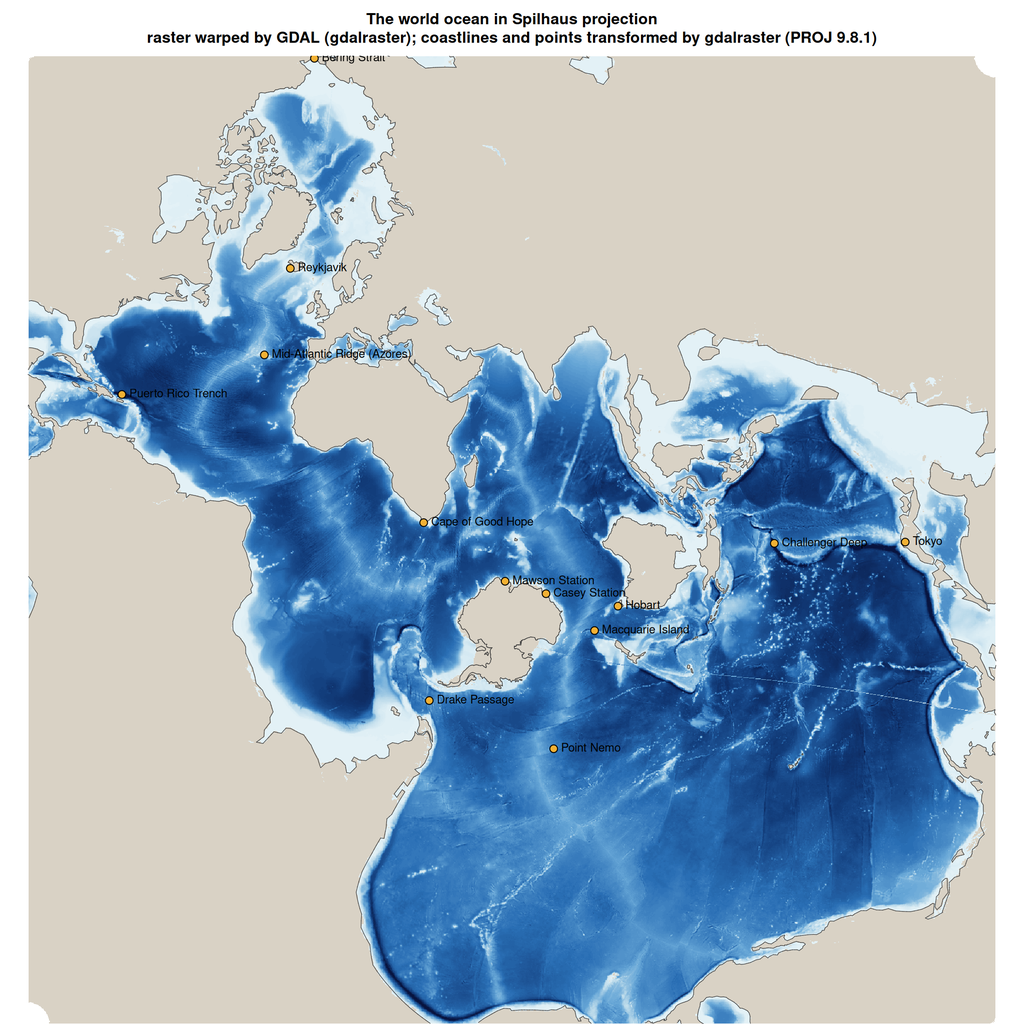

```r
composite <- function(z, half, segs, lm_xy, main) {
  op <- par(mar = c(0, 0, 3, 0), bg = "white")
  render_raster(z, half)
  segments(segs[, 1], segs[, 2], segs[, 3], segs[, 4], col = "#3a3a3a", lwd = 0.6)
  points(lm_xy, pch = 21, bg = "#f2b134", col = "black", cex = 1.1)
  text(lm_xy, rownames(landmarks), pos = 4, cex = 0.75, offset = 0.4)
  title(main, cex.main = 1)
  par(op)
}
proj_used <- provenance$proj[provenance$package == ENGINE]
composite(w$z, HALF, segs, lm_xy,
          sprintf("The world ocean in Spilhaus projection\nraster warped by GDAL (gdalraster); coastlines and points transformed by %s (PROJ %s)", ENGINE, proj_used))
```

## 7. Naming the thing: proj-string, WKT, and the missing authority code

Three renderings of “the same” projection. The bare proj-string exports to WKT with the method named and *no parameters*: the numbers live in PROJ’s source. Spell the parameters out and the WKT carries them. **ESRI:54099** is the only authority code you will find and it is a different, sqrt(2)-larger square, which PROJ expresses as `+k_0=1.41421356237`. There is no EPSG code.

```r
to_wkt <- function(x) tryCatch(gdalraster::srs_to_wkt(x, pretty = TRUE), error = function(e) paste("(", conditionMessage(e), ")"))
hobart <- function(x) tryCatch({ p <- safe(make_forward(x))(cbind(147.33, -42.88)); sprintf("%s, %s", format(round(p[1]), big.mark = ","), format(round(p[2]), big.mark = ",")) }, error = function(e) "transform failed")
renderings <- data.frame(
  rendering = c("bare proj-string", "explicit proj-string", "ESRI:54099", "alternative centre (section 8)"),
  input = c(SPILHAUS, SPILHAUS_EXPLICIT, "ESRI:54099", SPILHAUS_ALT))
renderings$hobart_xy <- vapply(renderings$input, hobart, "")
knitr::kable(renderings, caption = "Same projection, several names. hobart_xy is Hobart's projected coordinate under each.", row.names = FALSE)
```

Same projection, several names. hobart_xy is Hobart’s projected coordinate under each.

| rendering | input | hobart_xy |
| --- | --- | --- |
| bare proj-string | +proj=spilhaus | 2,583,897, -1,613,781 |
| explicit proj-string | +proj=spilhaus +lon_0=66.94970198 +lat_0=-49.56371678 +azi=40.17823482 +rot=45 +k_0=1 +x_0=0 +y_0=0 +R=6378137 | 2,577,441, -1,612,650 |
| ESRI:54099 | ESRI:54099 | 3,654,183, -2,282,231 |
| alternative centre (section 8) | +proj=spilhaus +lon_0=-30 +lat_0=-20 +azi=20 +rot=45 | 1,793,670, -9,342,479 |

```r
fence <- strrep("`", 3)
for (i in seq_len(nrow(renderings))) {
  cat("\n#### WKT2 for", renderings$rendering[i], "\n\n", fence, "\n", to_wkt(renderings$input[i]), "\n", fence, "\n", sep = "")
}
```

#### WKT2 forbare proj-string

```
PROJCS["unknown",
    GEOGCS["unknown",
        DATUM["WGS_1984",
            SPHEROID["WGS 84",6378137,298.257223563,
                AUTHORITY["EPSG","7030"]],
            AUTHORITY["EPSG","6326"]],
        PRIMEM["Greenwich",0,
            AUTHORITY["EPSG","8901"]],
        UNIT["degree",0.0174532925199433,
            AUTHORITY["EPSG","9122"]]],
    PROJECTION["custom_proj4"],
    UNIT["metre",1,
        AUTHORITY["EPSG","9001"]],
    AXIS["Easting",EAST],
    AXIS["Northing",NORTH],
    EXTENSION["PROJ4","+proj=spilhaus +datum=WGS84 +wktext +no_defs"]]
```

#### WKT2 forexplicit proj-string

```
PROJCS["unknown",
    GEOGCS["unknown",
        DATUM["unknown",
            SPHEROID["unknown",6378137,0]],
        PRIMEM["Greenwich",0,
            AUTHORITY["EPSG","8901"]],
        UNIT["degree",0.0174532925199433,
            AUTHORITY["EPSG","9122"]]],
    PROJECTION["custom_proj4"],
    UNIT["metre",1,
        AUTHORITY["EPSG","9001"]],
    AXIS["Easting",EAST],
    AXIS["Northing",NORTH],
    EXTENSION["PROJ4","+proj=spilhaus +lon_0=66.94970198 +lat_0=-49.56371678 +azi=40.17823482 +rot=45 +k_0=1 +x_0=0 +y_0=0 +R=6378137"]]
```

#### WKT2 forESRI:54099

```
PROJCS["WGS_1984_Spilhaus_Ocean_Map_in_Square",
    GEOGCS["WGS 84",
        DATUM["WGS_1984",
            SPHEROID["WGS 84",6378137,298.257223563,
                AUTHORITY["EPSG","7030"]],
            AUTHORITY["EPSG","6326"]],
        PRIMEM["Greenwich",0],
        UNIT["Degree",0.0174532925199433]],
    PROJECTION["Adams_Square_II"],
    PARAMETER["False_Easting",0],
    PARAMETER["False_Northing",0],
    PARAMETER["Scale_Factor",1],
    PARAMETER["Azimuth",40.17823482],
    PARAMETER["Longitude_Of_Center",66.94970198],
    PARAMETER["Latitude_Of_Center",-49.56371678],
    PARAMETER["XY_Plane_Rotation",45],
    UNIT["metre",1,
        AUTHORITY["EPSG","9001"]],
    AXIS["Easting",EAST],
    AXIS["Northing",NORTH],
    AUTHORITY["ESRI","54099"]]
```

#### WKT2 foralternative centre (section 8)

```
PROJCS["unknown",
    GEOGCS["unknown",
        DATUM["WGS_1984",
            SPHEROID["WGS 84",6378137,298.257223563,
                AUTHORITY["EPSG","7030"]],
            AUTHORITY["EPSG","6326"]],
        PRIMEM["Greenwich",0,
            AUTHORITY["EPSG","8901"]],
        UNIT["degree",0.0174532925199433,
            AUTHORITY["EPSG","9122"]]],
    PROJECTION["custom_proj4"],
    UNIT["metre",1,
        AUTHORITY["EPSG","9001"]],
    AXIS["Easting",EAST],
    AXIS["Northing",NORTH],
    EXTENSION["PROJ4","+proj=spilhaus +lon_0=-30 +lat_0=-20 +azi=20 +rot=45"]]
```

## 8. Another member of the family

Same method, different parameters: a naive recentring on the Atlantic. The square’s edges now slice the Pacific. Spilhaus’s contribution was the parameter choice, not the projection.

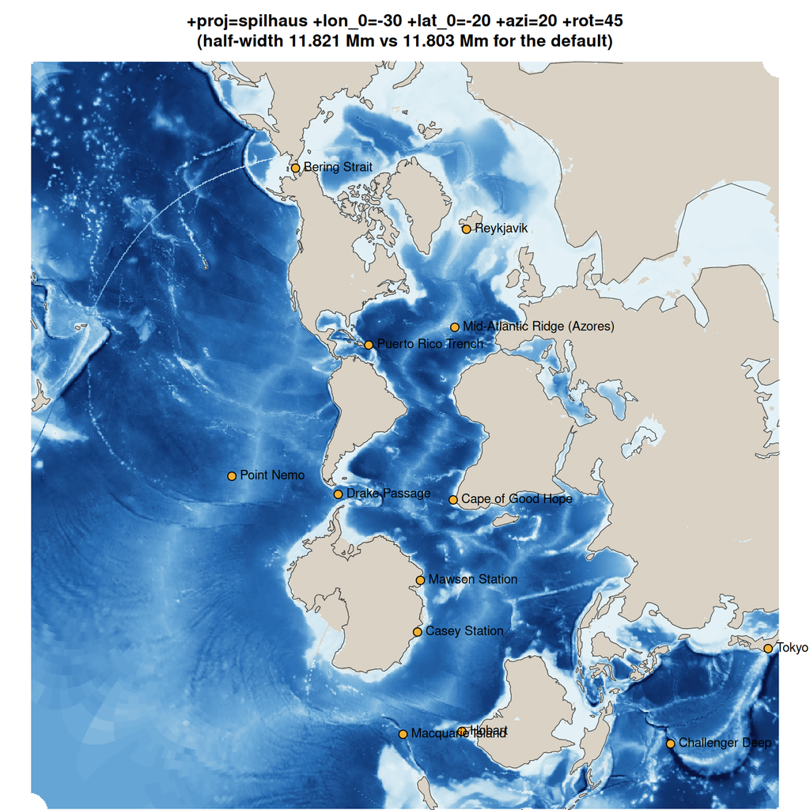

```r
forward_alt <- safe(make_forward(SPILHAUS_ALT))
HALF_ALT <- square_half(forward_alt)
w_alt <- warp_square(SPILHAUS_ALT, HALF_ALT, max(400L, NPIX %/% 2L), out = "/vsimem/spilhaus_alt.tif")
segs_alt <- coast_segments(geom, forward_alt, HALF_ALT)
composite(w_alt$z, HALF_ALT, segs_alt, forward_alt(landmarks),
          sprintf("%s\n(half-width %.3f Mm vs %.3f Mm for the default)", SPILHAUS_ALT, HALF_ALT / 1e6, HALF / 1e6))
```

## Appendix: the same thing in one line each

Convenience layers hide which PROJ did the work. Each of these either works or does not, purely according to the table in section 1.

```r
if (requireNamespace("sf", quietly = TRUE)) {
  x <- sf::st_transform(sf::st_sfc(sf::st_point(c(147.33, -42.88)), crs = "OGC:CRS84"), SPILHAUS)
  print(sf::st_coordinates(x)); cat("sf used PROJ", sf::sf_extSoftVersion()[["PROJ"]], "\n")
}
```

```
           X        Y
[1,] 2583897 -1613781
sf used PROJ 9.9.0
```

```r
if (requireNamespace("terra", quietly = TRUE)) {
  x <- terra::project(terra::vect(cbind(147.33, -42.88), crs = "OGC:CRS84"), SPILHAUS)
  print(terra::crds(x)); cat("terra used PROJ", terra::gdal(lib = "proj"), "\n")
}
```

```
           x        y
[1,] 2583897 -1613781
terra used PROJ 9.9.0
```